# A Simple Representative Growth Model

Lecturer: Bo Li

School of Economics, Peking University

TA: Chen Gao

chengao0716@gmail.com

National School of Development, Peking University

2026-03-20

# A Simple Representative Growth Model

## Brock and Mirman (1972)

- The social planner solves the following problem:
  $$\begin{gathered}
  \max _{\left\{c_{t}, k_{t+1}\right\}} \sum_{t=0}^{\infty} \beta^{t} \log \left(c_{t}\right) \\
  c_{t}+k_{t+1} \leq A k_{t}^{\alpha} \\
  k_{0} \text{ given, } c_{t}, k_{t} \geq 0 \text{ for all } t
  \end{gathered}$$
- The controls are $c_{t}$ and $k_{t+1}$, and the only state is $k_{t}$. We can reformulate the previous problem as a dynamic programming problem as follows:
  $$V(k) = \max_{k'} \left\{ \log \left( A k^{\alpha} - k' \right) + \beta V(k') \right\}$$
- If we solve for capital stock policy rule $k' = g_k(k)$, we can obtain the policy function for consumption $c = g_c(k)$ directly from the resource constraint:
  $$g_c(k) = A k^{\alpha} - g_k(k)$$

## Step 1: Initialization of the parameters

```python
import numpy as np
import matplotlib.pyplot as plt
import time

# Model Parameters
alpha = 0.4
A = 5
beta = 0.9888

# Algorithm Parameters
T = 20  # periods to simulate
tolv = 1e-8  # tolerance
```

## Steady State

To compute the steady state, we use the equilibrium conditions:
$$\begin{gathered}
\frac{1}{c} = \beta \frac{1}{c'}\left(\alpha A {k'}^{\alpha-1}\right) \\
c + k' = A k^{\alpha}
\end{gathered}$$
Imposing $x = x'$ for all variables, we get:
$$\begin{gathered}
k_{ss} = \left(\frac{1}{\beta \alpha A}\right)^{\frac{1}{\alpha-1}} \\
c_{ss} = A k_{ss}^{\alpha} - k_{ss} \\
y_{ss} = A k_{ss}^{\alpha}
\end{gathered}$$

The steady state is given by:

```python
k_ss = (1 / (beta * alpha * A)) ** (1 / (alpha - 1))
y_ss = A * k_ss**alpha
c_ss = y_ss - k_ss
ku = (1 / A) ** (1 / (alpha - 1))  # if c = 0

print("k_ss=", k_ss)
print("k_u=", ku)
```

```
k_ss= 3.1157606561253433
k_u= 14.62008869106433
```

## Step 2: Creation of a grid for the states

```python
lk = 500
k_min = 0.5 * k_ss
k_max = 1.5 * k_ss
k = np.linspace(k_min, k_max, num=lk)

print(k[:5])
```

```
[1.55788033 1.56412434 1.57036835 1.57661236 1.58285637]
```

## Step 3: Computation of the return function

- For each value of $k$ and $k'$ in the grid we need:
  $$\begin{aligned}
  c &= A k^{\alpha} - k' \\
  U(c) &= \log(c)
  \end{aligned}$$
- $U$ is of dimension $g_k \times 1$, where $g_k = l_k \times l_k$.
- If $l_k = 2$ , $U$ is of dimension $4 \times 1$:
  $$\begin{aligned}
  & \leftarrow k' \longrightarrow \\
  & \begin{aligned} &\uparrow \\ & k \\ &\downarrow \end{aligned} \left[ \begin{array}{l} c_{11} \\ c_{12} \\ c_{21} \\ c_{22} \end{array} \right] \\
  c_{ij} = A k_{i}^{\alpha} - k_{j} \quad \text{for} \ i=1:l_k,\, j=1:l_k
  \end{aligned}$$

```python
gk = lk * lk  # dimension of U

c = np.zeros((gk))
for i in range(lk):
    for j in range(lk):
        c[i * lk + j] = A * (k[i] ** alpha) - k[j]
        if c[i * lk + j] < 0:
            c[i * lk + j] = tolv
print(c)
```

```
[4.41224766 4.40600365 4.39975964 ... 4.60356373 4.59731972 4.59107571]
```

**Note**

Here we use **index packing**: the combination `i * lk + j` converts 2D indices `(i, j)` into a unique 1D index.

- This technique allows us to map a 2D grid (all possible pairs $(k_i, k_j)$) into a 1D array
- which is often needed for vectorized operations or storage efficiency in numerical computing

Finally, to calculate the return function, we simply take the log of the consumption vector:

```python
u = np.log(c)
print(u)
```

```
[1.48438423 1.48296808 1.48154991 ... 1.52683073 1.52547346 1.52411436]
```

## Step 4: Initialization and computation of the optimal value function

- Our candidate value function is an $l_k \times 1$ vector:
  $$V(k) = \begin{bmatrix}
  V(k_1) \\
  V(k_2) \\
  \vdots \\
  V(k_{l_k})
  \end{bmatrix}$$
- We can initialize $V_0$ with a vector of zeros of dimension $l_k$.
- We also need to initialize the contraction mapping operator $V_1 = T(V_0)$.
- In iteration $n$, it returns:
  $$V_n(k_i) = \max_{k'} \left\{ \begin{bmatrix}
  U(A k_i - k_1') \\ \vdots \\
  U(A k_i - k_{l_k}')
  \end{bmatrix}
  + \beta \begin{bmatrix}
  V_{n-1}(k_1') \\ \vdots \\
  V_{n-1}(k_{l_k}')
  \end{bmatrix}
  \right\}$$

## Value Function Iteration

In each iteration:

- Set $V_0$ to be the $V_1$ computed from the previous iteration.
- For each $k_i$, compute $U(c) + \beta V_0(k')$ and choose the maximum over $k'$ and call it $V_1$ (Use the max operator).
- Compare $V_0$ with $V_1$ and, if the difference is sufficiently small, stop (Use the norm of $V_1 - V_0$).

```python
# Initialize value function and operator and iterate
V0 = np.ones((lk))
V1 = np.zeros((lk))
start_time = time.time()
while abs(np.linalg.norm(V1 - V0)) > tolv:
    V0 = np.copy(V1)  # Use deepcopy here to avoid shallow copy.
    for i in range(lk):
        vtemp = u[i * lk : (i + 1) * lk] + beta * V0
        V1[i] = np.max(vtemp)

print(V1[:5])
print(f"Time taken: {time.time() - start_time:.2f} seconds")
```

```
[138.88421524 138.88686227 138.88949887 138.89212395 138.89474037]
Time taken: 1.57 seconds
```

## Convergence Criteria: Norm Choices

When checking convergence of value function iteration, we often monitor

$$\|V_{n+1}-V_n\|\le \texttt{tol}.$$
Different norms imply different (sometimes stronger/weaker) stopping rules.

### 1) Sup-norm ($\ell_\infty$): the standard for contraction mappings

$$\|x\|_\infty = \max_i |x_i|.$$

- **Interpretation:** the largest pointwise change in the value function.
- **Why common:** Bellman operators are contractions in $\|\cdot\|_\infty$ under standard conditions.

```python
diff = V1 - V0
err_inf = np.max(np.abs(diff))                 # ||V1 - V0||_inf
# or: err_inf = np.linalg.norm(diff, ord=np.inf)
print(err_inf)
```

```
4.4568082557816524e-10
```

### 2) Euclidean norm ($\ell_2$): average-magnitude change

$$|x|_2 = \left(\sum_i x_i^2\right)^{1/2}.$$

- **Interpretation:** overall magnitude of the change.
- **Caution:** small $\ell_2$ does not rule out a large error at a single grid point.

```python
diff = V1 - V0
err_2 = np.linalg.norm(diff, ord=2)            # ||V1 - V0||_2
# same as: err_2 = np.sqrt(np.sum(diff**2))
print(err_2)
```

```
9.96425562765096e-09
```

### 3) $\ell_1$ norm: total absolute change

$$|x|_1 = \sum_i |x_i|.$$

- **Interpretation:** aggregate absolute change across all grid points.
- **Caution:** depends on grid size (more points → larger sum), so tolerances are not comparable across lk.

```python
diff = V1 - V0
err_1 = np.linalg.norm(diff, ord=1)            # ||V1 - V0||_1
# same as: err_1 = np.sum(np.abs(diff))
print(err_1)
```

```
2.2280752887127164e-07
```

### 4) Relative norms: scale-free stopping rule

Absolute errors depend on the scale of $V$. A relative rule is
$$\frac{|V_{n+1}-V_n|}{\max(1,|V_n|)} \le \texttt{tol}.$$

```python
diff = V1 - V0
den = max(1.0, np.linalg.norm(V0, ord=np.inf))
rel_err_inf = np.max(np.abs(diff)) / den
print(rel_err_inf)
```

```
3.192300058330576e-12
```

### 5) Weighted norm (optional): emphasize important regions

Given weights $w_i>0$,

$$|x|_{w,\infty} = \max_i \frac{|x_i|}{w_i}.$$

Useful if some grid points matter more (e.g., near the ergodic distribution).

```python
diff = V1 - V0
w = np.ones_like(diff)          # replace with your weights (must be > 0)
err_winf = np.max(np.abs(diff) / w)
print(err_winf)
```

```
4.4568082557816524e-10
```

**Tip**

**Practical default:** use the sup-norm (`np.max(np.abs(V1 - V0))`) for VFI convergence checks, because it matches the standard contraction-mapping theory.

## Step 5: Computation of the optimal policy functions

- To calculate $g_k(k)$, for each point in the grid, find the index where $U(c) + \beta V^*(k')$ takes its maximum value when $V^*$ is used.
- The element `optim[i]` gives the index of the $k'$ maximizer when the initial capital is $k_i$.

```python
optim = np.zeros(lk, dtype="int") # "int" type for index.
for i in range(lk):
    vtemp = u[i * lk:(i + 1) * lk] + beta * V0
    optim[i] = np.argmax(vtemp)
print(optim[:5])
```

```
[129 129 130 130 131]
```

- The policy functions are given by:
  $$\begin{aligned}
  &\text{polk}=\begin{bmatrix}
  g_k(k_1) \\
  g_k(k_2) \\
  \vdots \\
  g_k(k_{l_k})
  \end{bmatrix},
  \text{polc}=\begin{bmatrix}
  g_c(k_1) \\
  g_c(k_2) \\
  \vdots \\
  g_c(k_{l_k})
  \end{bmatrix}
  \quad \text{and} \quad
  \text{polc}=A\begin{bmatrix}
  k_1 \\
  k_2 \\
  \vdots \\
  k_{l_k}
  \end{bmatrix}^{\alpha}-\begin{bmatrix}
  g_k(k_1) \\
  g_k(k_2) \\
  \vdots \\
  g_k(k_{l_k})
  \end{bmatrix}
  \end{aligned}$$

```python
polk = k[optim]
polc = A * k**alpha - polk

print(polk[:5])
print(polc[:5])
```

```
[2.36335753 2.36335753 2.36960154 2.36960154 2.37584555]
[3.60677046 3.61633032 3.6196233  3.62913757 3.63238525]
```

## Testing our approximation

The analytical solution to the model is:

$$\begin{gathered}
v(k) = (1-\beta)^{-1} \Big[ \ln (A(1-\alpha \beta)) + \frac{\alpha \beta}{1-\alpha \beta} \ln (A \alpha \beta) \Big] + \frac{\alpha}{1-\alpha \beta} \ln (k) \\
k' = g_k(k) = \alpha \beta A k^{\alpha} \\
c = g_c(k) = (1-\alpha \beta) A k^{\alpha}
\end{gathered}$$

To test our approximation, we compare the differences between the analytical and numerical solution.

```python
# True value functions
a = (1 / (1 - beta)) * (np.log(A * (1 - alpha * beta)) + alpha * beta * np.log(A * alpha * beta) / (1 - alpha * beta))
b = alpha / (1 - alpha * beta)
Vk = a + b * np.log(k)
dist = np.linalg.norm(Vk - V0)
print(f"Distance between true and approx. value function: {dist:.8f}")
```

```
Distance between true and approx. value function: 0.00038753
```

**Note**

**Why is the distance between the true and approximated value function not zero?**

The main reason is that the optimal policy function is not exact on the grid. If we increase the grid size, the distance will decrease.

Also, if we use a smaller tolerance, the distance will decrease.

Plot the true and approximated value functions:

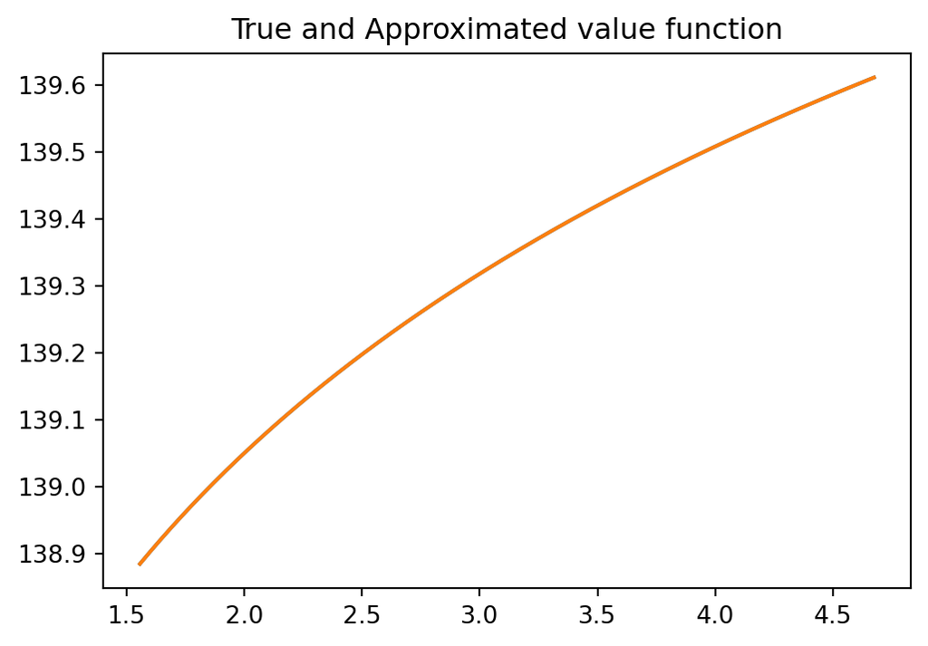

```python
plt.figure(figsize=(6, 4))
plt.plot(k, V0)
plt.plot(k, Vk)
plt.title("True and Approximated value function")
plt.show()
```

## Simulating the model

1. Choose an initial value for $k_0$. To do this, select a number between 1 and $I_k$, indicating the position in the initial capital in the grid. Given this position, we use the capital policy function to extract the optimal first period capital.
2. We then create a loop that:
   - given the position of $k_0$, finds the position of the optimal next period capital that corresponds to it.
   - uses the initial capital and the position of the new optimal capital to calculate the values of output, consumption, and the next period capital, using the optimal policy vectors.

**Note**

We need $lk = 500$ ($lk = 2$ is too small) to demonstrate the proper picture. To achieve this: change `lk` in step 2, run all above, then rerun the next cell.

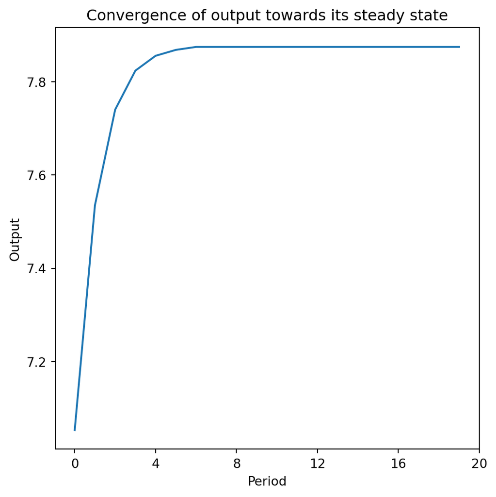

```python
indk = 0
kopt = np.zeros(T + 1)
output = np.zeros(T)
cons = np.zeros(T)

kopt[0] = polk[indk]

for i in range(T):
    indk = optim[indk]
    output[i] = A * kopt[i] ** alpha
    kopt[i + 1] = polk[indk]
    cons[i] = output[i] - kopt[i + 1]

plt.figure(figsize=(6, 6))
plt.plot(range(T), output)
plt.title("Convergence of output towards its steady state")
plt.xticks(range(0, T + 1, 4))
plt.xlabel("Period")
plt.ylabel("Output")
plt.show()
```

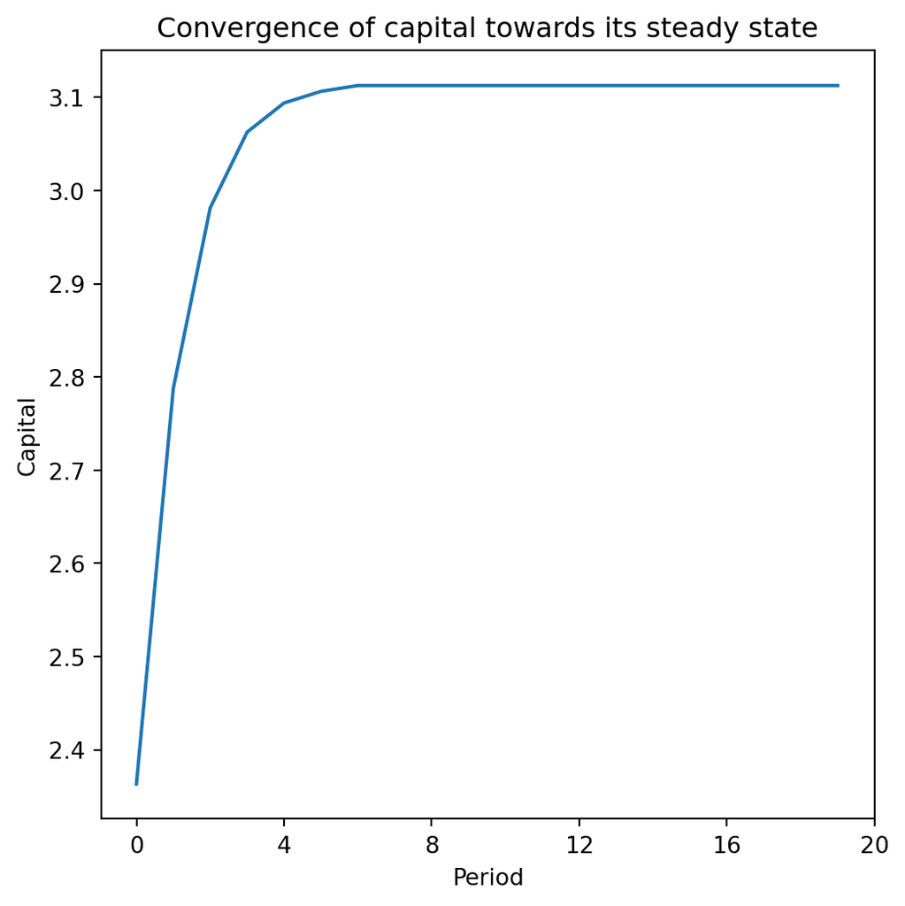

```python
plt.figure(figsize=(6, 6))
plt.plot(range(T), kopt[:T])
plt.title("Convergence of capital towards its steady state")
plt.xticks(range(0, T + 1, 4))
plt.xlabel("Period")
plt.ylabel("Capital")
plt.show()
```

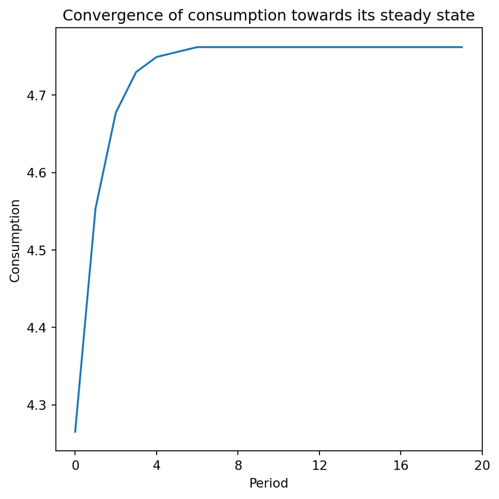

```python
plt.figure(figsize=(6, 6))
plt.plot(range(T), cons)
plt.title("Convergence of consumption towards its steady state")
plt.xticks(range(0, T + 1, 4))
plt.xlabel("Period")
plt.ylabel("Consumption")
plt.show()
```

# Brock and Mirman with iid shocks

## IID Shocks

- The social planner solves the following problem:
  $$\begin{gathered}
  \max_{\{c_t, k_{t+1}\}} E_0 \sum_{t=0}^\infty \beta^t \log(c_t) \\
  \text{s.t. } c_t + k_{t+1} \leq \theta_t k_t^\alpha \\
  \theta_t \in [\theta_1, \theta_2];\ \Pr(\theta_t = \theta_1) = \Pr(\theta_t = \theta_2) = 0.5 \\
  k_0, \theta_0 \text{ given; } c_t, k_t \geq 0 \ \forall t
  \end{gathered}$$
- The controls are $c_t$, $k_{t+1}$; the states are $k_t$ and $\theta_t$.<sup>1</sup>
- We can formulate as a dynamic programming problem:
  $$V(k, \theta) = \max_{k'} \left\{ \log(\theta_t k^\alpha - k') + \beta \mathbb{E} V(k', \theta') \right\}$$
- We have to solve for:
  $$\begin{aligned}
  k' &= g_k(k, \theta) \\
  g_c(k, \theta) &= \theta k^\alpha - g_k(k, \theta)
  \end{aligned}$$
[^1]: We assume that the shock $\theta$ is iid and the expected value of the shock is $1$.

## Step 1: Initialization of the parameters and steady state

```python
# Model Parameters
alpha = 0.4
beta = 0.9888

# Algorithm Parameters
T = 20  # periods to simulate
tolv = 1e-8  # tolerance
```

## Steady State

- To calculate the steady state, we use:
  $$\begin{gathered}
  \frac{1}{c} = \beta \mathbb{E} \frac{1}{c'} (\alpha \theta' {k'}^{\alpha-1}) \\
  c + k' = k^{\alpha}
  \end{gathered}$$
- With $\mathbb{E}(\theta') = \mathbb{E}(\theta) = 1$ , and $x = x'$ for all variables, we get:
  $$\begin{gathered}
  k_{ss} = \left(\frac{1}{\beta \alpha}\right)^{\frac{1}{\alpha-1}} \\
  c_{ss} = k_{ss}^\alpha - k_{ss} \\
  y_{ss} = k_{ss}^\alpha
  \end{gathered}$$

```python
# steady state
k_ss = (1 / (beta * alpha)) ** (1 / (alpha - 1))
y_ss = k_ss ** alpha
c_ss = y_ss - k_ss

print("k_ss=", k_ss)
```

```
k_ss= 0.21311503110303762
```

## Step 2: Creation of a grid for the states

- Create a grid vector for $\theta$ and $k$ with $l_\theta$ and $l_k$ values:
  $$\theta \in [\theta_1, \ldots, \theta_{l_\theta}],\quad k \in [k_1, \ldots, k_{l_k}]$$

```python
lt = 2
theta = np.linspace(1 + 1.625 / 100, 1 - 1.625 / 100, num=lt)
print(theta)

lk = 500
k_min = 0.5 * k_ss
k_max = 1.5 * k_ss
k = np.linspace(k_min, k_max, num=lk)
print(k[:5])
```

```
[1.01625 0.98375]
[0.10655752 0.1069846  0.10741168 0.10783877 0.10826585]
```

## Step 3: Computation of the return function

- For each value of $\theta, k$ and $k'$, calculate:
  $$\begin{gathered}
  c = \theta k^{\alpha} - k' \\
  U(c) = \log(c)
  \end{gathered}$$
- Create a matrix of dimensions $g_k \times l_\theta$, where $g_k = l_k \times l_k$.

```python
gk = lk * lk
c = np.zeros((gk, lt))
for t in range(lt):
    for i in range(lk):
        for j in range(lk):
            c[i * lk + j][t] = theta[t] * k[i] ** alpha - k[j]
            if c[i * lk + j][t] < 0:
                c[i * lk + j][t] = tolv
print(c[:5])
```

```
[[0.3084292  0.29515779]
 [0.30800211 0.29473071]
 [0.30757503 0.29430362]
 [0.30714795 0.29387654]
 [0.30672086 0.29344945]]
```

To calculate the return function, simply take the log of the consumption matrix:

```python
u = np.log(c)
print(u[:5])
```

```
[[-1.17626296 -1.22024518]
 [-1.17764863 -1.2216932 ]
 [-1.17903622 -1.22314332]
 [-1.18042574 -1.22459554]
 [-1.18181719 -1.22604987]]
```

## Step 4: Initialization and computation of the optimal value function

- Our candidate solution for the value function is an $l_k \times l_\theta$ matrix:
  $$V(k, \theta) =
  \begin{bmatrix}
  V(k_1, \theta_1) & V(k_1, \theta_2) \\
  V(k_2, \theta_1) & V(k_2, \theta_2) \\
  \vdots & \vdots \\
  V(k_{l_k}, \theta_1) & V(k_{l_k}, \theta_2)
  \end{bmatrix}$$
- Initialize $V_0$ as zeros of dimension $l_k \times l_\theta$ and $V_1 = T(V_0)$. At iteration $n$, calculate:
  $$V_n(k_i, \theta_t) = \max_{k'} \left\{
  \begin{bmatrix}
  U(\theta_t k_i^\alpha - k_1') \\
  \vdots \\
  U(\theta_t k_i^\alpha - k_{l_k}')
  \end{bmatrix}
  + \beta \begin{bmatrix}
  \sum_{m=1}^2 \frac{1}{2} V_{n-1}(k_1', \theta_m') \\
  \vdots \\
  \sum_{m=1}^2 \frac{1}{2} V_{n-1}(k_{l_k}', \theta_m')
  \end{bmatrix}
  \right\}$$

## Value Function Iteration

```python
# Initialize value function and operator and iterate
V0 = np.ones((lk, lt))
V1 = np.zeros((lk, lt))
p = np.array([0.5, 0.5])
start_time = time.time()
while abs(np.linalg.norm(V1 - V0)) > tolv:
    V0 = np.copy(V1)
    for j in range(lt):
        for i in range(lk):
            vtemp = u[i * lk : (i + 1) * lk, j] + beta * V0 @ p
            V1[i, j] = np.max(vtemp)
V0 = np.copy(V1)
print(V0[:5])
print(f"Time taken: {time.time() - start_time:.2f} seconds")
```

```
[[-100.6080923  -100.66186288]
 [-100.60544596 -100.65921516]
 [-100.60280894 -100.65657915]
 [-100.60018353 -100.65395331]
 [-100.59756785 -100.65133759]]
Time taken: 5.05 seconds
```

## Step 5: Computation of the optimal policy functions

For each point in the grid, we find the index of the capital maximizer using the max operator.

```python
optim = np.zeros((lk, lt), dtype="int") # "int" type for index.
for j in range(lt):
    for i in range(lk):
        vtemp = u[i * lk:(i + 1) * lk, j] + beta * V0 @ p
        optim[i, j] = np.argmax(vtemp)
print(optim[:5])
```

```
[[135 123]
 [135 123]
 [136 124]
 [137 124]
 [137 125]]
```

Using this matrix, the policy functions can be calculated as follows:

$$\begin{gathered}
\text{polk} =
\begin{bmatrix}
g_k(k_1, \theta_1) & g_k(k_1, \theta_2) \\
\vdots & \vdots \\
g_k(k_{l_k}, \theta_1) & g_k(k_{l_k}, \theta_2)
\end{bmatrix},
\text{polc} =
\begin{bmatrix}
g_c(k_1, \theta_1) & g_c(k_1, \theta_2) \\
\vdots & \vdots \\
g_c(k_{l_k}, \theta_1) & g_c(k_{l_k}, \theta_2)
\end{bmatrix} \\
\quad \text{and} \quad
\text{polc} = \begin{bmatrix}
\theta_1 k_1^\alpha & \theta_2 k_1^\alpha \\
\vdots & \vdots \\
\theta_1 k_{l_k}^\alpha & \theta_2 k_{l_k}^\alpha
\end{bmatrix} - \text{polk}
\end{gathered}$$

```python
polk = k[optim]
print(polk[:5])
```

```
[[0.16421389 0.15908888]
 [0.16421389 0.15908888]
 [0.16464097 0.15951596]
 [0.16506806 0.15951596]
 [0.16506806 0.15994304]]
```

## Simulating the model

1. Choose an initial value for $k_0$ and $\theta_0$ and use the policy matrix to extract the optimal first-period capital.
2. We then create a loop that:
   - given the initial capital and shock, finds the position of the optimal next period capital.
   - uses the initial capital, the initial shock index, and the next capital to calculate output, consumption, and stores variables for each period. It also generates a new shock index for next period.

```python
indk = 1
shock = 1
kopt = np.zeros(T + 1)
sho = np.zeros(T)
output = np.zeros(T)
cons = np.zeros(T)

kopt[0] = polk[indk, shock]

for i in range(T):
    indk = optim[indk, shock]
    sho[i] = theta[shock]
    kopt[i + 1] = polk[indk, shock]
    output[i] = theta[shock] * kopt[i] ** alpha
    cons[i] = output[i] - kopt[i + 1]
    shock = np.random.randint(0, 2)
```

## Plotting the results

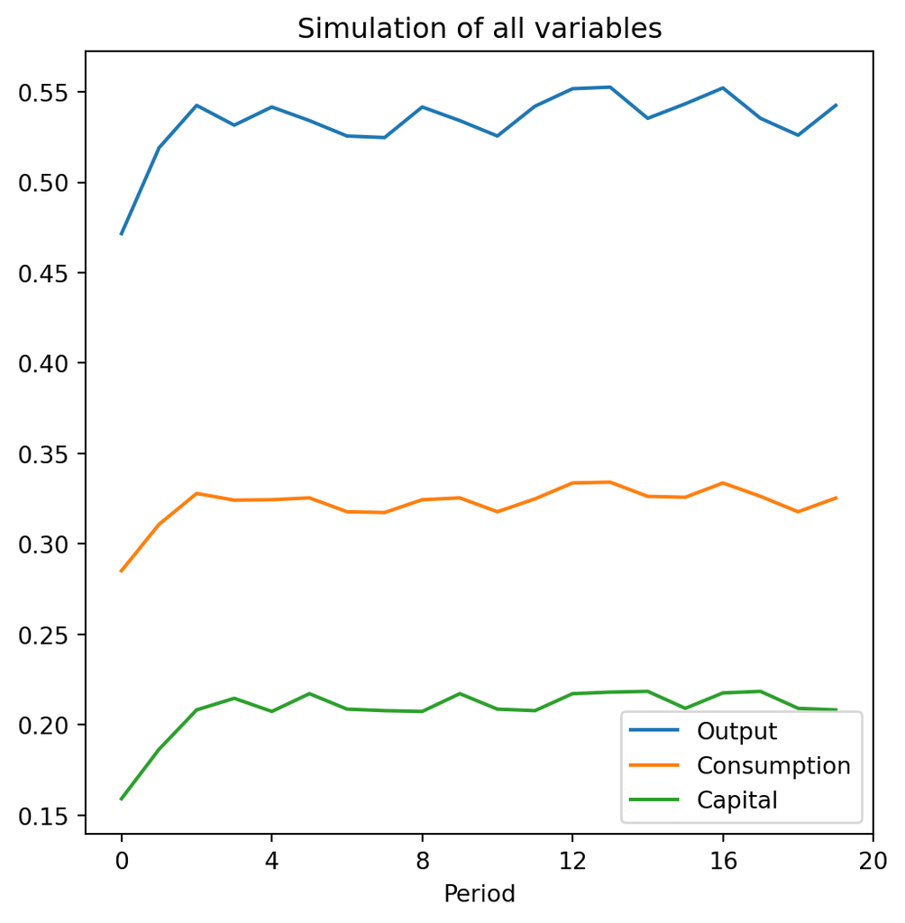

```python
plt.figure(figsize=(6, 6))
plt.plot(range(T), output, label="Output")
plt.plot(range(T), cons, label="Consumption")
plt.plot(range(T), kopt[:T], label="Capital")
plt.title("Simulation of all variables")
plt.xticks(range(0, T + 1, 4))
plt.xlabel("Period")
plt.legend()
plt.show()
```

# Stochastic Growth Model with Markov Shocks

## Markov-Chain Approximation of AR(1) Productivity Shocks

Let the (finite) state space be $S= \{\theta_1,\dots,\theta_N\}$.

- **Markov property (memorylessness).** For any $i,j$,
  $$\Pr(\theta_{t+1}=\theta_j \mid \theta_t=\theta_i,\theta_{t-1},\dots)
  =\Pr(\theta_{t+1}=\theta_j\mid \theta_t=\theta_i)=P_{ij}.$$
- **Transition matrix** $P\in\mathbb R^{N\times N}$:
  $$P_{ij}\ge 0,\qquad \sum_{j=1}^N P_{ij}=1\ \ \forall i=1,2,...,N.$$
- **Stationary (invariant) distribution.** A vector $\pi\in\Delta^{N-1}$ is stationary if
  $$\pi^\top=\pi^\top P,\qquad \pi_i\ge 0,\ \sum_i \pi_i=1.$$
  If the chain is **irreducible** and **aperiodic** (ergodic), then $\pi$ is unique and for any initial distribution $\mu_0$,
  $$\mu_t^\top=\mu_0^\top P^t \to \pi^\top.$$
- **How expectations enter DP.** If current shock is $\theta=\theta_i$,
  $$\mathbb E\!\left[V(k',\theta')\mid \theta=\theta_i\right]\ \approx\ \sum_{j=1}^N P_{ij}\,V(k',\theta_j).$$

## Approximating AR(1) shocks: Tauchen (1986) discretization

- It is standard to discretize **log productivity** to ensure positivity.
- Assume
  $$x_t=\rho x_{t-1}+\varepsilon_t,\qquad \varepsilon_t\sim N(0,\sigma^2),\qquad \theta_t=\exp(x_t).$$
- **(i) Choose a grid** of $N$ states for $x$
  - Unconditional standard deviation:
    $$\sigma_x=\frac{\sigma}{\sqrt{1-\rho^2}}.$$
  - Pick a truncation width $m>0$ (often $m=3$) and set
    $$x_1=-m\sigma_x,\quad x_N=m\sigma_x,\quad x_i=x_1+(i-1)\Delta,\quad \Delta=\frac{x_N-x_1}{N-1}.$$
- **(ii) Build the transition matrix**
  - Define interval cutoffs
    $$b_{j-}=x_j-\frac{\Delta}{2},\qquad b_{j+}=x_j+\frac{\Delta}{2},$$
    with $b_{1-}=-\infty$ and $b_{N+}=+\infty$. Then
    $$P_{ij}
    =\Pr(x_{t+1}\in[b_{j-},b_{j+}]\mid x_t=x_i)
    =\Phi\!\left(\frac{b_{j+}-\rho x_i}{\sigma}\right)-\Phi\!\left(\frac{b_{j-}-\rho x_i}{\sigma}\right),$$
    where $\Phi(\cdot)$ is the standard normal CDF.

**Note**

When $\rho$ is close to $1$ and $N$ is small, Rouwenhorst (1995) often matches persistence better than Tauchen (1986).

## Step 1: Initialization of the parameters and steady state

```python
# Model and Algorithm Parameters
delta = 0.1
alf = 0.33
A = 1
beta = 0.9
gamma = 2
tolv = 1e-7
```

## Construction of a Markov Chain

We use the `quantecon` library to construct a Markov Chain.

- First, we set up the parameter values for the AR(1) process that drives the aggregate productivity shock.
- We then use Tauchen’s method to discretize this process into a finite Markov chain.

```python
# Step 1: Specify the AR(1) process parameters and discretize with Tauchen's method
import quantecon as qe

rho = 0.95  # persistence of the AR(1) process
sigmae = 0.00712  # standard deviation of the error term
lt = 4  # number of grid states for the Markov chain
n_std = 3  # number of standard deviations to cover in the grid

# Use Tauchen's method to approximate the AR(1) with a Markov chain
x_mc = qe.markov.approximation.tauchen(rho=rho, sigma=sigmae, n_std=n_std, n=lt, mu=0)
```

- Next, we extract the transition matrix, the grid for the state variable representing productivity shocks, compute the values of productivity in levels (by exponentiating), and obtain the stationary distribution over states.

```python
# Step 2: Extract transition matrix and productivity states, and compute stationary distribution
P = x_mc.P  # transition matrix (to match standard notation)
x_grid = x_mc.state_values  # discretized grid for the state variable
teta = np.exp(x_grid)  # productivity in levels, since shock is in logs
invdist = np.array(x_mc.stationary_distributions)  # stationary distribution
print(f"Stationary distribution: {invdist}")
print(f"Productivity states: {teta}")
print(f"Transition matrix: {P[0,:]}")
print(f"Check (sum of first row): {np.sum(P[0,:])}")
```

```
Stationary distribution: [[0.05317954 0.44682046 0.44682046 0.05317954]]
Productivity states: [0.93388054 0.97745576 1.02306421 1.07080077]
Transition matrix: [0.99675735 0.00324265 0.         0.        ]
Check (sum of first row): 1.0
```

**Note**

The transition matrix `P[i,j]` denotes the probability of transitioning from state `i` to state `j`. That is:
$$P_{ij} = \Pr(x_{t+1} \in [b_{j-}, b_{j+}] \mid x_t = x_i) = \Pr(x_{t+1}=x_j \mid x_t = x_i)$$

## Steady State

The equilibrium is given by:
$$\begin{gathered}
c^{-\gamma} = \beta E[(c')^{-\gamma} (\alpha \theta' A {k'}^{\alpha-1} + 1-\delta) ] \\
c + i = \theta A k^\alpha \\
i = k' - (1-\delta)k
\end{gathered}$$

Imposing $\theta_{ss} = E \theta' = E \theta$ and $x = x'$ gives:

$$\begin{gathered}
k_{ss} = \left(\frac{1-\beta(1-\delta)}{\beta \alpha A \theta_{ss}}\right)^{\frac{1}{\alpha-1}} \\
i_{ss} = \delta k_{ss} \\
c_{ss} = \theta_{ss} A k_{ss}^{\alpha} - i_{ss} \\
y_{ss} = A \theta_{ss} k_{ss}^{\alpha}
\end{gathered}$$

```python
Eteta = invdist @ teta
k_ss = (A * Eteta * alf * beta / (1 - beta * (1 - delta))) ** (1 / (1 - alf))
y_ss = Eteta * A * (k_ss**alf)
i_ss = delta * k_ss
c_ss = y_ss - i_ss
print(k_ss)
```

```
[1.94925376]
```

**Caution**

Note that `k_ss` is actually a `nd.array` of shape `(1,)`. This is because `Eteta` is a `nd.array` of shape `(1,)` not a scalar (`float`).

## Step 2: Creation of a grid for the states

Create a grid for the shock and for $k$ with $l_k$ values, i.e. $k \in [k_1 < \ldots < k_{l_k}]$.

```python
# Grid for capital
lk = 500
k_min = 0.9 * k_ss
k_max = 1.1 * k_ss
k = np.linspace(k_min, k_max, num=lk)
print(k[:5])
```

```
[[1.75432839]
 [1.75510965]
 [1.75589092]
 [1.75667218]
 [1.75745344]]
```

## Step 3: Computation of the return function

For each $\theta, k$ and $k'$, calculate:
$$\begin{aligned}
c = \theta A k^\alpha + (1-\delta)k - k' \\
U(c) = \frac{c^{1-\gamma}}{1-\gamma}
\end{aligned}$$

```python
gk = lk * lk
c = np.zeros((gk, lt))
for t in range(lt):
    for i in range(lk):
        for j in range(lk):
            c[i * lk + j][t] = A * teta[t] * k[i] ** alf + (1 - delta) * k[i] - k[j]
            if c[i * lk + j][t] < 0:
                c[i * lk + j][t] = tolv
print(c[0, :])
```

```
[0.9487784  1.00123451 1.05613825 1.11360382]
```

To calculate the return function, take logs if $\gamma = 1$, or compute $\frac{c^{1-\gamma}}{1-\gamma}$ otherwise.

```python
if gamma == 1:
    U = np.log(c)
else:
    U = c ** (1 - gamma) / (1 - gamma)
print(U[0, :])
```

```
[-1.0539869  -0.99876701 -0.94684574 -0.89798543]
```

## Step 4: Initialization and computation of the optimal value function

Our candidate solution for the value function is an $l_k \times l_\theta$ matrix.

```python
# Initialize of the value function
V0 = np.ones((lk, lt))
V1 = np.zeros((lk, lt))
start_time = time.time()
while abs(np.linalg.norm(V1 - V0)) > tolv:
    V0 = np.copy(V1)
    for j in range(lt):
        for i in range(lk):
            vtemp = U[i * lk : (i + 1) * lk, j] + beta * V0 @ P[j, :]
            V1[i, j] = np.max(vtemp)

V0 = np.copy(V1)
print(V0[0, :])
end_time = time.time()
print(f"Time taken: {end_time - start_time} seconds")
```

```
[-10.5240125   -9.98068286  -9.45989273  -8.96829951]
Time taken: 2.6193039417266846 seconds
```

## Step 5: Computation of the optimal policy functions

```python
optim = np.zeros((lk, lt), dtype="int")
for j in range(lt):
    for i in range(lk):
        vtemp = U[i * lk : (i + 1) * lk, j] + beta * V0 @ P[j, :]
        optim[i, j] = np.argmax(vtemp)
print(optim[0, :])
```

```
[ 0 20 42 64]
```

- For each pair $(\theta_j, k_i)$, `optim[i, j]` is the index of the next period capital maximizer.
- If $l_k = 2$ and $l_\theta = 4$, the policy functions are:
  $$\begin{aligned}
  & \text{polk} =
  \begin{bmatrix}
  g_k(k_1, \theta_1) & g_k(k_1, \theta_2) & g_k(k_1, \theta_3) & g_k(k_1, \theta_4) \\
  g_k(k_2, \theta_1) & g_k(k_2, \theta_2) & g_k(k_2, \theta_3) & g_k(k_2, \theta_4)
  \end{bmatrix} \\
  & \text{polc} =
  \begin{bmatrix}
  \theta_1 k_1^\alpha & \theta_2 k_1^\alpha & \theta_3 k_1^\alpha & \theta_4 k_1^\alpha \\
  \theta_1 k_2^\alpha & \theta_2 k_2^\alpha & \theta_3 k_2^\alpha & \theta_4 k_2^\alpha
  \end{bmatrix}
  + (1-\delta) \begin{bmatrix}
  k_1 & k_1 & k_1 & k_1 \\
  k_2 & k_2 & k_2 & k_2
  \end{bmatrix}
  - \text{polk}
  \end{aligned}$$

```python
polk = k[optim]
print(polk[0, :])
```

```
[[1.75432839]
 [1.76995367]
 [1.78714148]
 [1.80432929]]
```

## Simulating the model

1. Choose an initial value for $k_0$ and $\theta_0$ and use the policy matrix to extract the optimal first period capital.
2. In a loop:
   - given the initial capital and shock, find the optimal next period capital.
   - use the current values to compute and store output, consumption, and capital, generating a new shock index for next period.

```python
T = 2000                      # simulate longer if you want moments
burn = 200                    # burn-in to remove dependence on initial state

# initial indices
ik = lk // 2                  # start near middle of k grid
s  = np.argmax(invdist)       # start at most likely shock state (or pick 0)

k_path = np.empty(T+1)
c_path = np.empty(T)
y_path = np.empty(T)
i_path = np.empty(T)
theta_path = np.empty(T, dtype=float)
s_path = np.empty(T, dtype=int)

k_path[0] = k[ik]

rng = np.random.default_rng(123)  # reproducible
```

```python
for t in range(T):
    theta = teta[s]
    theta_path[t] = theta
    s_path[t] = s

    # policy: choose next capital index and level
    ik_next = optim[ik, s]
    k_next  = k[ik_next]

    # compute flows from resource constraint
    y = theta * A * (k_path[t] ** alf)
    i = k_next - (1 - delta) * k_path[t]
    c = y - i

    # store
    y_path[t] = y
    i_path[t] = i
    c_path[t] = c
    k_path[t+1] = k_next

    # update indices
    ik = ik_next
    s = rng.choice(lt, p=P[s, :])   # Markov transition
```

```python
# drop burn-in
k_sim = k_path[burn:]
c_sim = c_path[burn:]
y_sim = y_path[burn:]
i_sim = i_path[burn:]
theta_sim = theta_path[burn:]

print("Simulation moments (post burn-in):")
print(f"E[k]={k_sim.mean():.4f} E[c]={c_sim.mean():.4f} E[y]={y_sim.mean():.4f}")
print(f"min(c)={c_sim.min():.4f} min(i)={i_sim.min():.4f}")
```

```
Simulation moments (post burn-in):
E[k]=1.9399 E[c]=1.0469 E[y]=1.2409
min(c)=0.9491 min(i)=0.1719
```

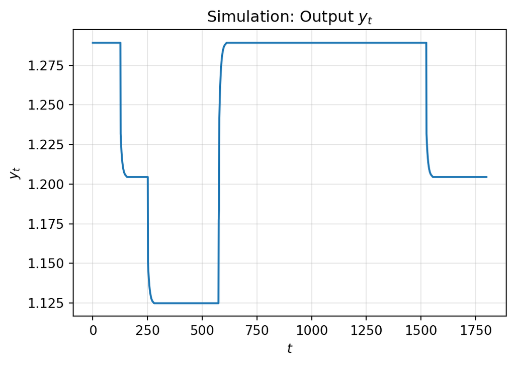

```python
plt.figure(figsize=(6, 4))
plt.plot(range(len(y_sim)), y_sim)
plt.title("Simulation: Output $y_t$")
plt.xlabel("$t$")
plt.ylabel("$y_t$")
plt.grid(True, alpha=0.3)
plt.show()
```

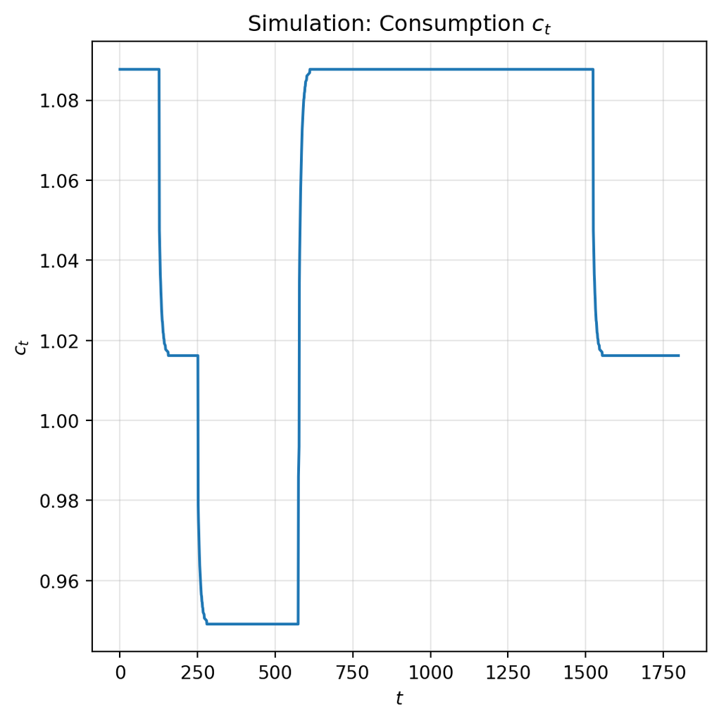

```python
plt.figure(figsize=(6, 6))
plt.plot(range(len(c_sim)), c_sim)
plt.title("Simulation: Consumption $c_t$")
plt.xlabel("$t$")
plt.ylabel("$c_t$")
plt.grid(True, alpha=0.3)
plt.show()
```

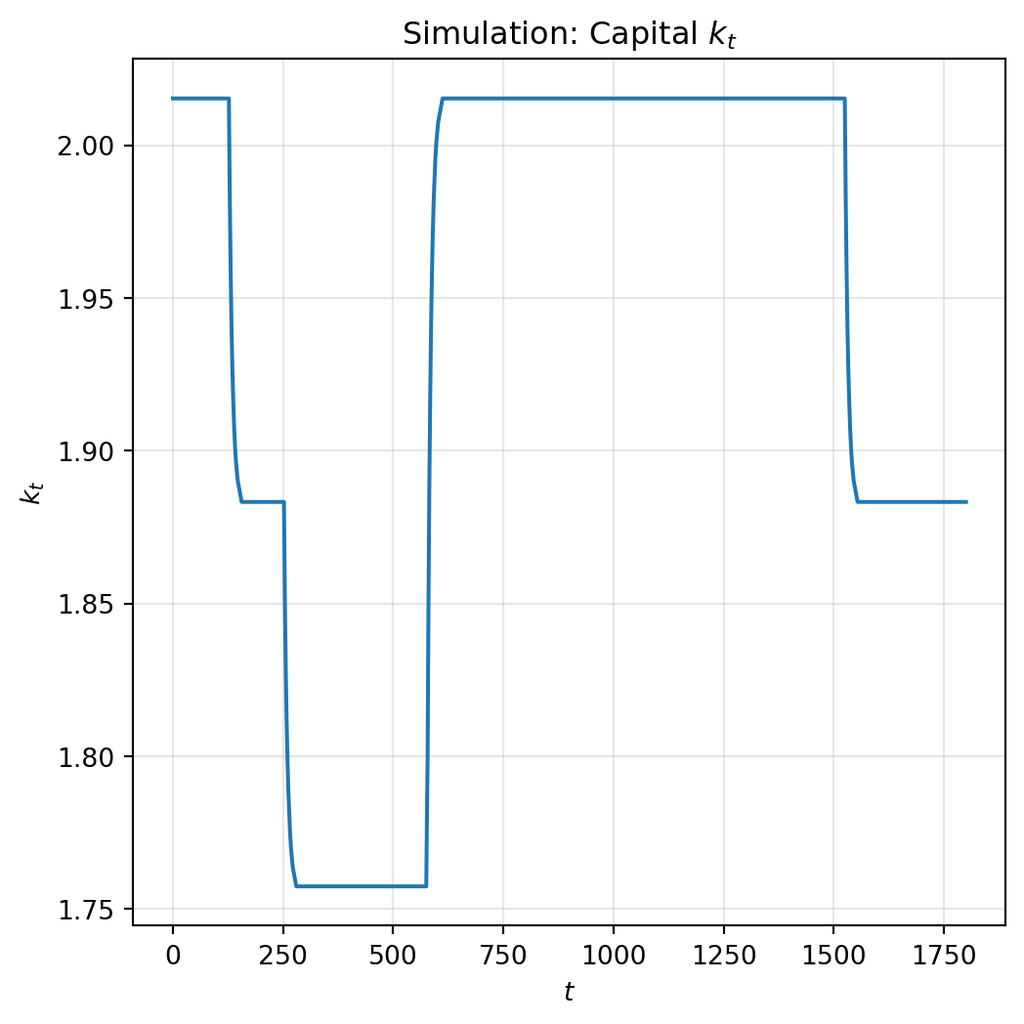

```python
plt.figure(figsize=(6, 6))
plt.plot(range(len(k_sim)), k_sim)
plt.title("Simulation: Capital $k_t$")
plt.xlabel("$t$")
plt.ylabel("$k_t$")
plt.grid(True, alpha=0.3)
plt.show()
```

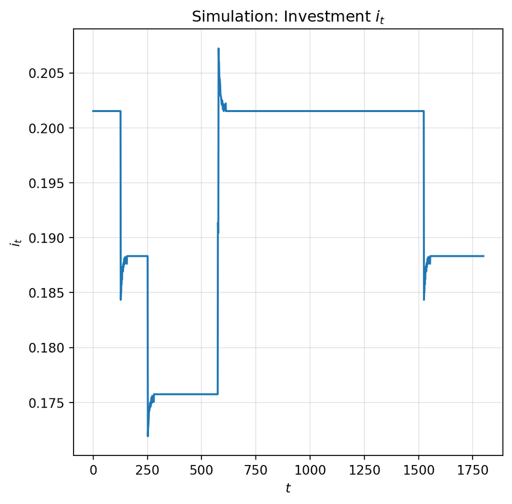

```python
plt.figure(figsize=(6, 6))
plt.plot(range(len(i_sim)), i_sim)
plt.title("Simulation: Investment $i_t$")
plt.xlabel("$t$")
plt.ylabel("$i_t$")
plt.grid(True, alpha=0.3)
plt.show()
```

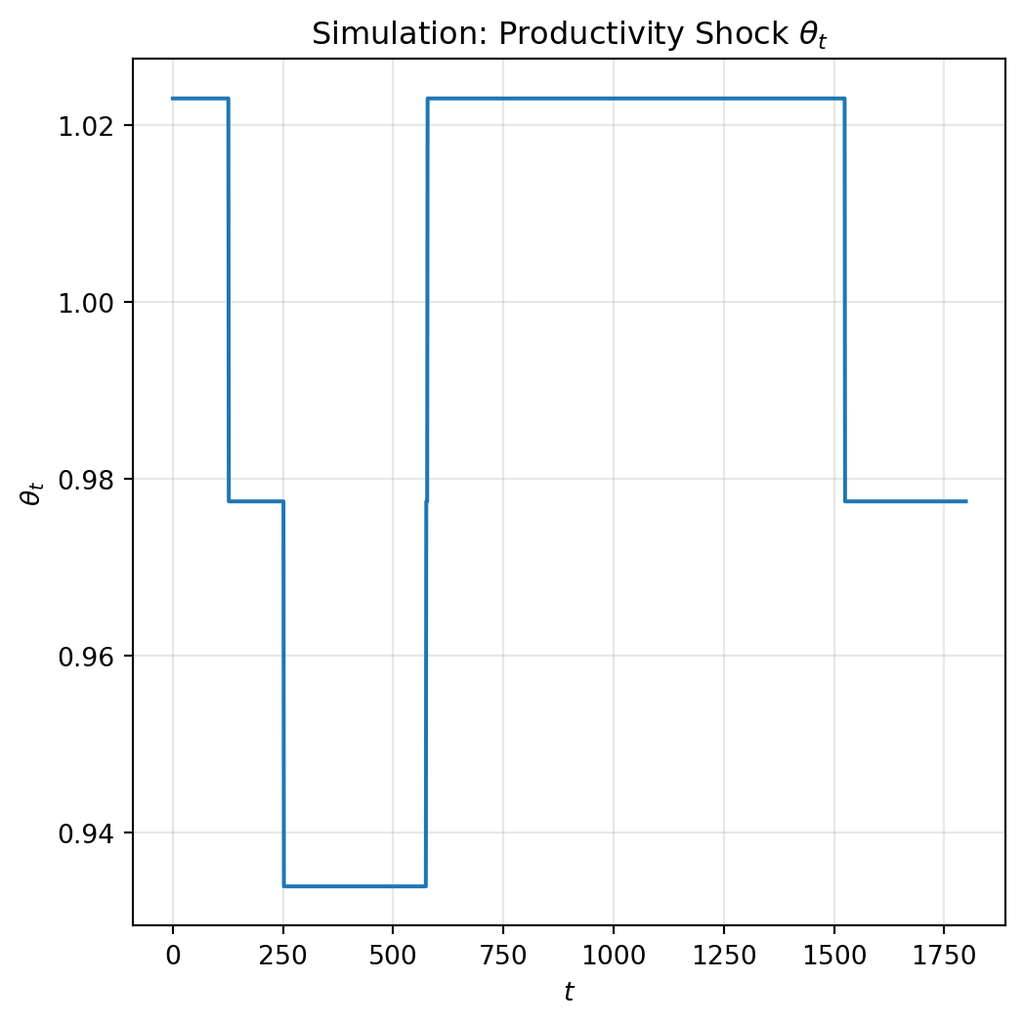

```python
plt.figure(figsize=(6, 6))
plt.plot(range(len(theta_sim)), theta_sim)
plt.title(r"Simulation: Productivity Shock $\theta_t$")
plt.xlabel("$t$")
plt.ylabel(r"$\theta_t$")
plt.grid(True, alpha=0.3)
plt.show()
```

# Exercise: Stochastic Growth Model with Irreversible Investment

## Irreversible Investment

The social planner solves the following problem:

$$\begin{gathered}
\max_{\{c_t, k_{t+1}\}} E_0 \sum_{t=0}^\infty \beta^t \frac{c_t^{1 - \gamma}}{1 - \gamma} \\
c_t + i_t \leq \theta_t A k_t^{\alpha} \\
k_{t+1} = i_t + (1 - \delta) k_t \\
i_t \geq 0
\end{gathered}$$

## References

Brock, William A., and Leonard J. Mirman. 1972. “Optimal Economic Growth and Uncertainty: The Discounted Case.” *Journal of Economic Theory* 4 (3): 479–513.

Rouwenhorst, K. Geert. 1995. “Asset Pricing Implications of Equilibrium Business Cycle Models.” *Handbooks in Operations Research and Management Science* 9: 945–74.

Tauchen, George. 1986. “Finite State Markov-Chain Approximations to Univariate and Vector Autoregressions.” *Economics Letters* 20 (2): 177–81.